# MLH1 Data Report

26 September 2019

# Research Description

Measure nMLH1 foci per meiotic cell to estimate recombination rate for diverse strains of house mice and related rodents. Comparison the differences in recombination rates across sexes and genetic background to inform models of how meiotic recombination rates evolve.

## Discription of quantification process

Cell images are quantified in batches after file names are anonymized. The number of MLH1 foci, number of “achiasmate” and asynasped bivalents are quantified. A quality score is given; 1 to 5 (best to worst). All cell image file names are anonymized and moved into batches of a few hundred images.

## Missing Mice, finishing dataset

*Which mice are remaining and at what stage?*

This section shows the number of mice which haven’t been stained or quantified yet.

| category | number.of.mice |
| --- | --- |
| Passed Quantified | 188 |
| Total Quantified | 194 |
| Non-Quantified | 187 |
| Non-Imaged | 255 |

passed quantified - quantified mice (with enough cells) total quantified – all mice which have been (includes fail and passing mice)

non-quantified mice – dissected mice / slides that haven’t been quantified yet (all stained, but without image directory)

non-imaged – mice without images, (might be stained and unstained)

This is the number of mice that are through different parts of the pathway or quantification process.

should I break down the categories into sex and strain?

## Repeatability of Human quantification

Well, we have to talk about the subjective nature that goes into scoring the MLH1 foci. Sources of error or variance across scoring come from background noise (false positives), faint foci (false negatives) and just human error. A general anecdote is that if the quality of the cell staining / image is high, then the repeatability is near 100%. (using some of Beth’s data). Todo: track down, re-count of Beth’s data, cells that were counted first then in batch 0 (anonimized)

Datasets / sources of repeat measures -chrom proportions -multiple batch counts (later than batch0) *focus on this dataset for now. since its >100 and fairly easy to compile -old and new (batch0)

The main take away is that higher quality scored cells have lower error in MLH1 counts.

> Does the amount of error differ across strains or sexes? (female might have a higher error rate)

> What sort of adjustments or tests should be made to results or analyses given the known error rate?

[output not shown]

[output cut: 200 more lines]

```
## [1] 31
```

|  | Var1 | Freq |
| --- | --- | --- |
| 99 | 20jul15_18may15_PWD_m2_sp1_10.1_rev.tif_Batch0 | 2 |
| 292 | 6mar15_1mar15_PWD_m1_sp4_6.1_rev.tif_Batch0 | 2 |

```
## [1] 178
```

Data use for this repeatabiity estimate is from smaller dataset where the proportions of chromosome/bivalent classes (0CO bivalents ect.) were quantified. (The focus of one count was cell total, while the other focus was classifying bivalents).

This data has 102 cells across these categories

| Var1 | Freq |
| --- | --- |
| WSB female | 4 |
| WSB male | 7 |
| G male | 9 |
| LEW female | 6 |
| LEW male | 11 |
| PWD female | 4 |
| PWD male | 6 |
| MSM female | 7 |
| MSM male | 12 |
| SKIVE female | 9 |
| SKIVE male | 7 |
| KAZ female | 8 |
| KAZ male | 7 |
| AST male | 3 |
| TOM male | 2 |

More cells are planned to be quantified.

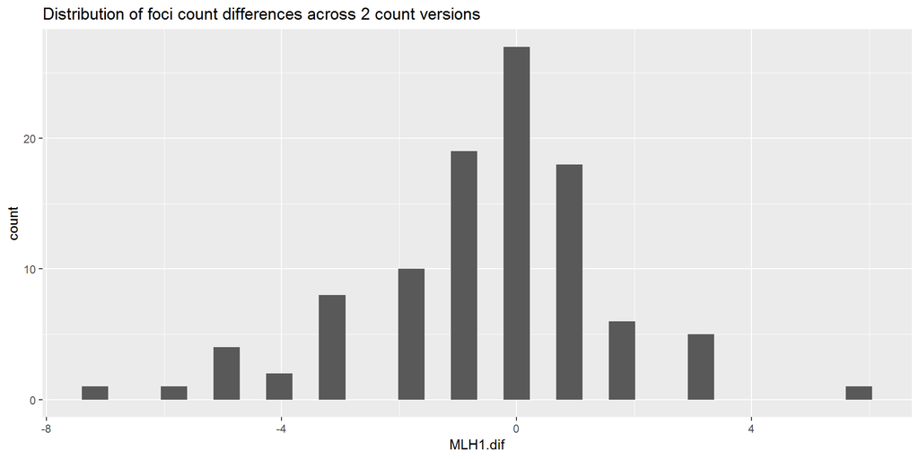

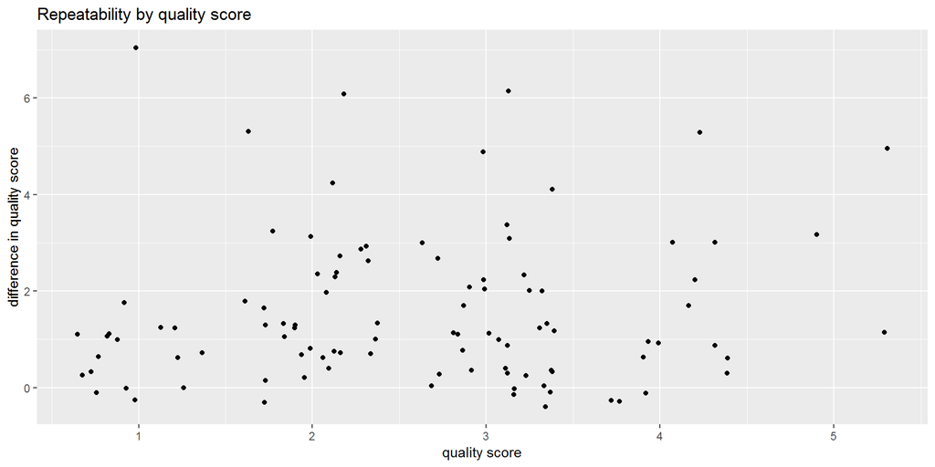

There is a positive relationship with the absolute difference and quality score (where 1 is best and 5 is worst quality) (i.e. poorer quality cells are more likely to have more error acorss multiple counts). The proportion of the cells which had the same count across the counting instances is 0.2647059. The correlation between the two versions of MLH1 counts for the same cell is 0.8749636.

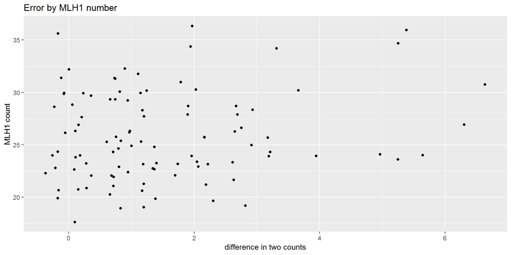

There doesn’t seem to be a bias across cells with more or less foci.

Modeling this relationship; (still in progress) I tried doing a logistic regression for same_count = true or false depending on the quality score. I am having trouble making a plot the makes sense to confirm the binomial nature of the model.

## Effects on the dataset

error associated with ‘quality of cels’

Main metric is mean CO count per mouse. Run tests to check if there are effects for the following effects.

*age effects* (male, maternal age)

*litter effect*

*mouse room effect* (Charmony, MSC)

*quantification repeatability*

*spread batch and staining effects*

*power analysis on number of cells*

*time of year effect (on spread)*

*dominant effect* (F1s)

These aspects will be analyzed with a linear models on subsets of data (within category) and visualized with plots.

### Quality effect

There is a positive correlation with MLH1 number and quality To test this effect, compare all of the counts from quality-1 cells across strains. check that the same patterns of means persist compared to the total-cell data.

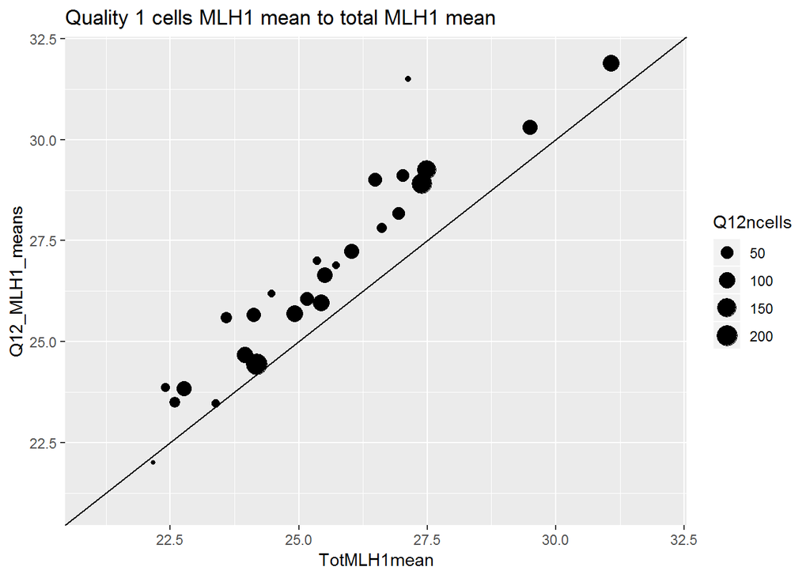

High quality cells

| category | subsp | ncells | nmice | mean.MLH1 |
| --- | --- | --- | --- | --- |
| WSB male | Dom | 100 | 11 | 24.67925 |
| G male | Dom | 209 | 14 | 24.44019 |
| LEW male | Dom | 111 | 10 | 25.68468 |
| PERC male | Dom | 16 | 1 | 23.87500 |
| PWD male | Musc | 82 | 8 | 30.31325 |
| MSM male | Musc | 105 | 7 | 31.89524 |
| MOLF male | Musc | 32 | 4 | 25.59375 |
| SKIVE male | Musc | 46 | 3 | 28.17391 |
| KAZ male | Musc | 78 | 9 | 23.84615 |
| CZECH male | Musc | 1 | 1 | 22.00000 |
| AST male | Musc | 12 | 2 | 27.00000 |
| CAST male | Cast | 28 | 2 | 23.50000 |
| HMI male | Cast | 10 | 2 | 26.20000 |
| SPRET male | Spretus | 60 | 5 | 26.06667 |
| SPIC male | Spic | 76 | 4 | 27.23684 |
| CAROLI male | Caroli | 22 | 1 | 27.81818 |
| other | other | 13 | 1 | 23.46154 |
| NA | NA | 1 | 1 | NA |

Total Cell

| category | subsp | ncells | nmice | mean.MLH1 |
| --- | --- | --- | --- | --- |
| WSB male | Dom | 253 | 12 | 23.95390 |
| G male | Dom | 313 | 14 | 24.18850 |
| LEW male | Dom | 287 | 10 | 24.92334 |
| PERC male | Dom | 30 | 1 | 22.40000 |
| PWD male | Musc | 172 | 8 | 29.50000 |
| MSM male | Musc | 176 | 7 | 31.07386 |
| MOLF male | Musc | 142 | 6 | 23.59155 |
| SKIVE male | Musc | 89 | 3 | 26.94382 |
| KAZ male | Musc | 221 | 9 | 22.76923 |
| CZECH male | Musc | 6 | 1 | 22.16667 |
| AST male | Musc | 51 | 2 | 25.35294 |
| TOM male | Musc | 14 | 1 | 23.50000 |
| CAST male | Cast | 49 | 2 | 22.59184 |
| HMI male | Cast | 52 | 4 | 24.46154 |
| SPRET male | Spretus | 112 | 5 | 25.15179 |
| SPIC male | Spic | 156 | 6 | 26.01923 |
| CAROLI male | Caroli | 33 | 1 | 26.60606 |
| other | other | 21 | 1 | 23.38095 |

When quality 1 to 2 is compared, the strains were closer to the line, but the means are still higher in the higher quality cells. with 1-2 most all of the difference are below 10% (except SPRET female).

MOLF males have quite a big difference.

There seem to be the similar amount of polymorphism in the Dom and more conserved in Dom.

Ranges of category means across subspecies.

| Type | male Dom | female Dom |  | male Musc low | male Musc high | Musc female |  | male Outgroup | female outgroup |
| --- | --- | --- | --- | --- | --- | --- | --- | --- | --- |
| Total cells | 22-24 | 24-27 |  | 23-31 | 25-31 | 26-29 |  | 25-26 | 27 |
| High quality cells | 23-25 | 25-29 |  | 22-25 | 22-27 | 25 |  | 26-27 | 29-31 |

(ASTmale in Musc high, has a 27 mean which might be an outlier) I think the ranges across the groups is generally consistant.

(try looking at <5 quality scores?)

> *How do the distributions change across different quality scores?*

Higher quality scored cells have more MLH1 foci. (some of the ranges get smaller with higher quality cells)

> *How do the distributions change across mice with a good number of cells?*

(was I referring to normale distributions?) means all shift up, what about variance, range, lowest cut off

> *Do the directions of the differences across groups change due to quality scores?*

(polymorphism vs divergence patterns)

### Age Effect

Some papers have documented age effects for male genome-wide recombination rate (cite, one of the Cole papers).

The initial analysis uses plots. This should be double checked with a general linear model as well.

Make a subsetted dataset for plotting mean mouse (quality < 5) MLH1 count and age.

I will try doing a logistic regression for embryonic vs neonate. The embyonic estimates likely aren’t very accurate, and there won’t be good sampling across time points.

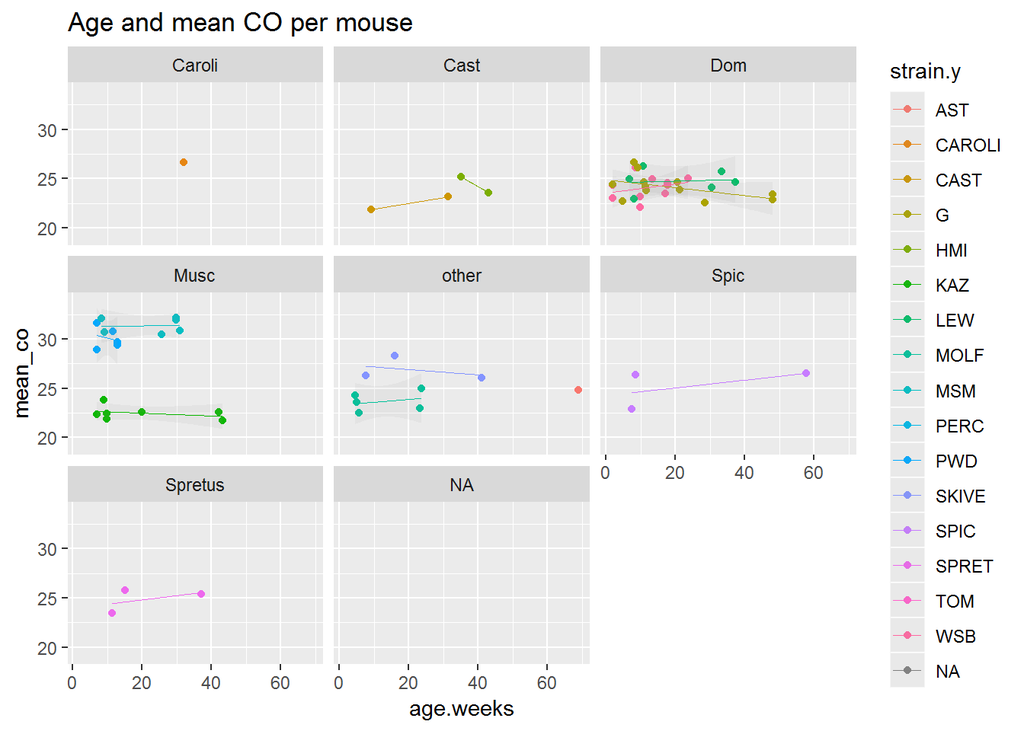

While many slopes are different than 0, I am not convinced there is a clear age effect. Most strains don’t have more than 2 ages. I will double check some of these mice and check a general linear model.

### Maternal Age effect

Check if there is a maternal age effect for females and males.

### Litter effect

Compare female spreads made on the same day, but from different mothers/litters.

### Spread and Stain Effects

> *month dissected*

For mice strains that have a similar MLH1 level (control for strain MLH1 effect), check if a month effect for MLH1 count (as seen in Peromyscus).

> *staining batches*

Compare observations from the same mouse, but different MLH1 stains.

### Cell number (power analysis results)

# Initial Results

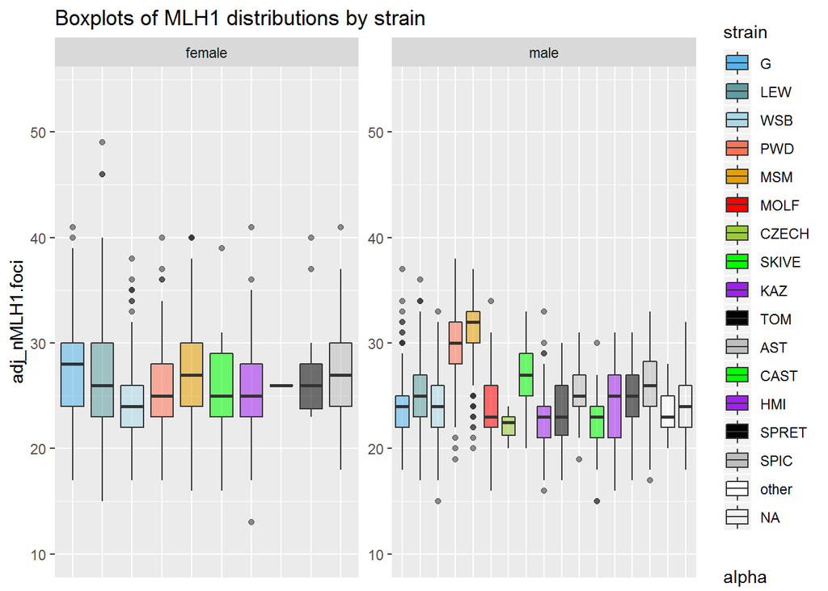

*What is the initial picture of Heterochiasmy across mouse strains?*

For the strain level plots -facet,sex by species

> *-Which strain has highest HetC?*

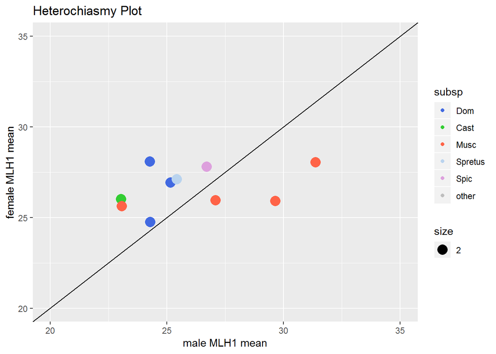

3 of my Musc strains have male biased patter; SKIVE, PWD and MSM. 1 of the musc strains has female biased heterochiasmy, KAZ.

### Distributions of MLH1 counts

> *Are the MLH1 distributions close to normal?*

(most all distributions are close to normal)

How do these compare to Poisson? (mean == variance) I should make ‘expected’ distributions behind these.

Human quantification seems to be biased towards rating cells with more MLH1 foci as higher quality. Unbiased cell quality assignment, would not show a positive correlation with quality and nMLH1. (CAST female data is fake)

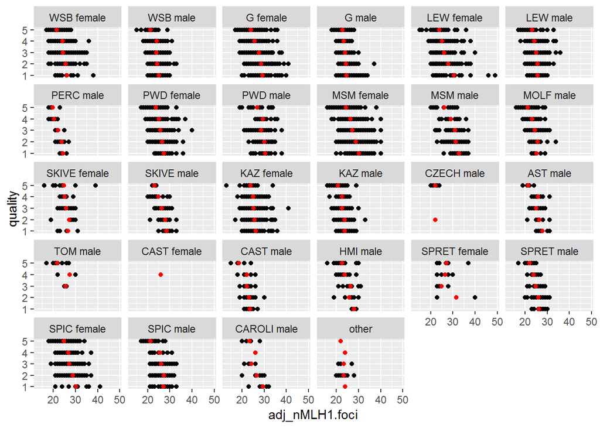

MLH1 means and quality scores

I plotted the mean of each quality bin with a red dot. From the pattern of the red dots, there is definitely a negative relationship with quality and nMLH1 foci across the data. This is most pronounced in MSM males and least pronounced in G males. The CAST female data is dummy data.

#### Distributions by mouse

> *Is there mouse level MLH1 quality score bias?*

Below are code chunks that make a big dfs of CO count by quality score plot. The code has been commented out, and moved to it’s own doc.

The mouse specific scatter plots aren’t show here because there are too bulky. These plots are in a different document.

Making all of these scatter plots, allows us to look at the whole distributions of the data for each mouse. The distance of the red line from the black could be a indicator of slides or mice with slide specific technical noise.

# Research Questions

## Explaination for the XX and XY differences

(in progress)

## Difference in proportion of chrm classes

generate smaller data set of chrm proportions (0CO, 1CO,2CO ect) 10 cells from each musc category.

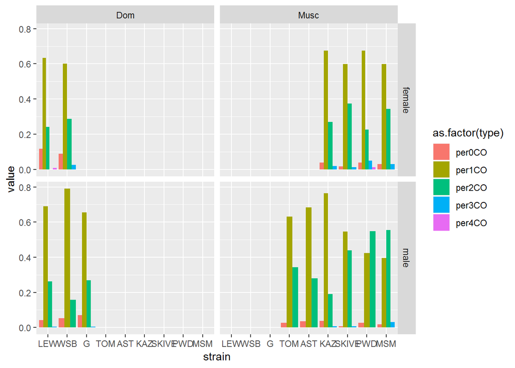

PWD and MSM have a higher proportion of 2CO chrms!

what about the variance across cells?

## Models for manuscript

Ideas for models of evolution of Heterochiasmy and current idea for how to test them.

- HetC arises due to more precursors (DSBs)
  - Compare DSB counts
- Larger cell volume drives longer chrms axis (and maybe more DSB)
  - Measure meiocyte diameter in males and females. Compare spermatocyte diameters in male biased and female biased strains.
  - Compare DSBs counts and average SC/axis lengths.
- Difference in astral/MT organization
  - ?
- Something about interference and sister cohesin area
  - Develope metric for sister cohesin area, and look at initial patterns.

## Mixed Model, compare within and between subspecies patterns

Initial results indicate that male MLH1 counts have less variance within subspecies but more between subspecies compared to female data.

*Does this hold up with the full data set?* *What’s the best visualization for these questions?*

Main focus is contrasting the level of difference within and between subspecies.

I’ll do this with a mixed model framework approach (and analyze with ANOVA, a method to partition the variance of subset.)

## Meiotic Error

This section reviews all the data from achiasmy and 0CO bivalents.

### Another Heterochiasmy Plot

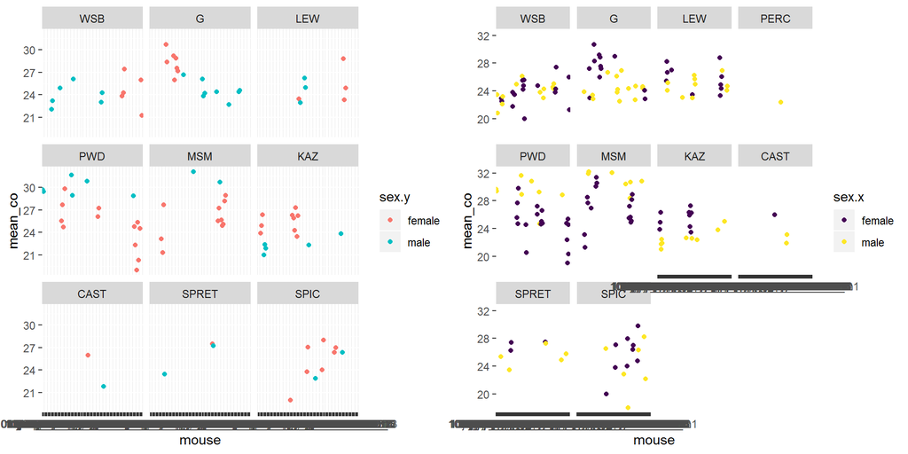

## SC.skel measures

data has been collection for RWang’s total SC. These results are consistant with the patterns seen in the bivalent level resutls. (total SC PWD > KAZ )

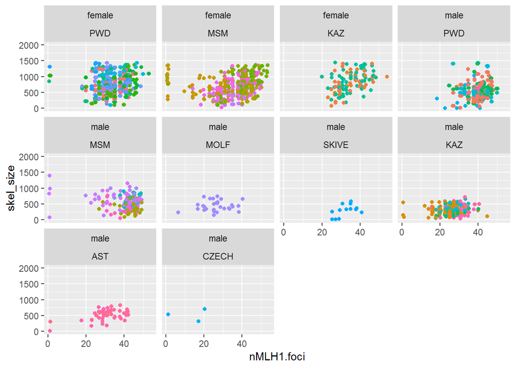

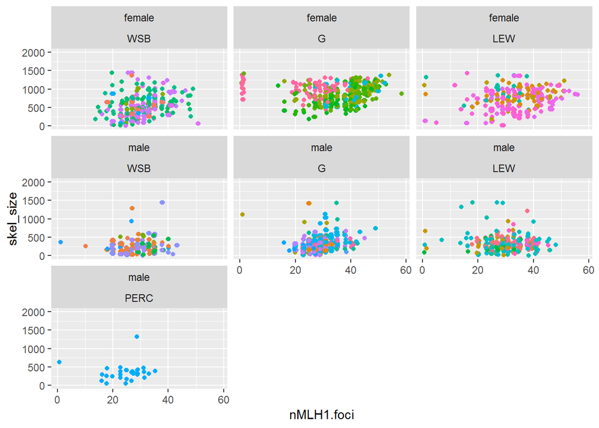

sis-coten metric: I am currently missing a null model / test for this metric (sis-co-ten from uniform placement of COs, and (some prob of draw for CO number))

there is a positive correlation with siscoten and chrm length

there could be something about kinetochore sites differing across specific chromosomes that balance the force